# Divvy Bike Share User Analysis

Ekeoma E. AGU

## Setup environment

The packages for data cleaning and analysis are loaded

```r
library(tidyverse)
library(lubridate)
library(skimr)
library(naniar)
```

## Get data

Uploading all Divvy trip data from October 2021 - September 2022 (the past 12 months)

```r
# Get files from working directory
data_files <- list.files(file.path(getwd(), "data"))

for(i in 1:length(data_files)){
  assign(paste0("month_", i),
         read.csv(paste0(getwd(), "/data/", data_files[i])))
}
```

## Review and Join dataframes to into one

Here we verify that the column naming convention and data types are consistent across all twelve data files to ensure the accuracy of the data set.

```r
glimpse(month_1)
```

```
## Rows: 631,226
## Columns: 13
## $ ride_id            <chr> "620BC6107255BF4C", "4471C70731AB2E45", "26CA69D43D~
## $ rideable_type      <chr> "electric_bike", "electric_bike", "electric_bike", ~
## $ started_at         <chr> "2021-10-22 12:46:42", "2021-10-21 09:12:37", "2021~
## $ ended_at           <chr> "2021-10-22 12:49:50", "2021-10-21 09:14:14", "2021~
## $ start_station_name <chr> "Kingsbury St & Kinzie St", "", "", "", "", "", "",~
## $ start_station_id   <chr> "KA1503000043", "", "", "", "", "", "", "", "", "",~
## $ end_station_name   <chr> "", "", "", "", "", "", "", "", "", "", "", "", "",~
## $ end_station_id     <chr> "", "", "", "", "", "", "", "", "", "", "", "", "",~
## $ start_lat          <dbl> 41.88919, 41.93000, 41.92000, 41.92000, 41.89000, 4~
## $ start_lng          <dbl> -87.63850, -87.70000, -87.70000, -87.69000, -87.710~
## $ end_lat            <dbl> 41.89000, 41.93000, 41.94000, 41.92000, 41.89000, 4~
## $ end_lng            <dbl> -87.63000, -87.71000, -87.72000, -87.69000, -87.690~
## $ member_casual      <chr> "member", "member", "member", "member", "member", "~
```

```r
glimpse(month_2)
```

```
## Rows: 359,978
## Columns: 13
## $ ride_id            <chr> "7C00A93E10556E47", "90854840DFD508BA", "0A7D10CDD1~
## $ rideable_type      <chr> "electric_bike", "electric_bike", "electric_bike", ~
## $ started_at         <chr> "2021-11-27 13:27:38", "2021-11-27 13:38:25", "2021~
## $ ended_at           <chr> "2021-11-27 13:46:38", "2021-11-27 13:56:10", "2021~
## $ start_station_name <chr> "", "", "", "", "", "Michigan Ave & Oak St", "", ""~
## $ start_station_id   <chr> "", "", "", "", "", "13042", "", "", "", "", "", ""~
## $ end_station_name   <chr> "", "", "", "", "", "", "", "", "", "", "", "", "",~
## $ end_station_id     <chr> "", "", "", "", "", "", "", "", "", "", "", "", "",~
## $ start_lat          <dbl> 41.93000, 41.96000, 41.96000, 41.94000, 41.90000, 4~
## $ start_lng          <dbl> -87.72000, -87.70000, -87.70000, -87.79000, -87.630~
## $ end_lat            <dbl> 41.96, 41.92, 41.96, 41.93, 41.88, 41.90, 41.80, 41~
## $ end_lng            <dbl> -87.73, -87.70, -87.70, -87.79, -87.62, -87.63, -87~
## $ member_casual      <chr> "casual", "casual", "casual", "casual", "casual", "~
```

```r
glimpse(month_3)
```

```
## Rows: 247,540
## Columns: 13
## $ ride_id            <chr> "46F8167220E4431F", "73A77762838B32FD", "4CF4245205~
## $ rideable_type      <chr> "electric_bike", "electric_bike", "electric_bike", ~
## $ started_at         <chr> "2021-12-07 15:06:07", "2021-12-11 03:43:29", "2021~
## $ ended_at           <chr> "2021-12-07 15:13:42", "2021-12-11 04:10:23", "2021~
## $ start_station_name <chr> "Laflin St & Cullerton St", "LaSalle Dr & Huron St"~
## $ start_station_id   <chr> "13307", "KP1705001026", "KA1504000117", "KA1504000~
## $ end_station_name   <chr> "Morgan St & Polk St", "Clarendon Ave & Leland Ave"~
## $ end_station_id     <chr> "TA1307000130", "TA1307000119", "13137", "KP1705001~
## $ start_lat          <dbl> 41.85483, 41.89441, 41.89936, 41.89939, 41.89558, 4~
## $ start_lng          <dbl> -87.66366, -87.63233, -87.64852, -87.64854, -87.682~
## $ end_lat            <dbl> 41.87197, 41.96797, 41.93758, 41.89488, 41.93125, 4~
## $ end_lng            <dbl> -87.65097, -87.65000, -87.64410, -87.63233, -87.644~
## $ member_casual      <chr> "member", "casual", "member", "member", "member", "~
```

```r
glimpse(month_4)
```

```
## Rows: 103,770
## Columns: 13
## $ ride_id            <chr> "C2F7DD78E82EC875", "A6CF8980A652D272", "BD0F91DFF7~
## $ rideable_type      <chr> "electric_bike", "electric_bike", "classic_bike", "~
## $ started_at         <chr> "2022-01-13 11:59:47", "2022-01-10 08:41:56", "2022~
## $ ended_at           <chr> "2022-01-13 12:02:44", "2022-01-10 08:46:17", "2022~
## $ start_station_name <chr> "Glenwood Ave & Touhy Ave", "Glenwood Ave & Touhy A~
## $ start_station_id   <chr> "525", "525", "TA1306000016", "KA1504000151", "TA13~
## $ end_station_name   <chr> "Clark St & Touhy Ave", "Clark St & Touhy Ave", "Gr~
## $ end_station_id     <chr> "RP-007", "RP-007", "TA1307000001", "TA1309000021",~
## $ start_lat          <dbl> 42.01280, 42.01276, 41.92560, 41.98359, 41.87785, 4~
## $ start_lng          <dbl> -87.66591, -87.66597, -87.65371, -87.66915, -87.624~
## $ end_lat            <dbl> 42.01256, 42.01256, 41.92533, 41.96151, 41.88462, 4~
## $ end_lng            <dbl> -87.67437, -87.67437, -87.66580, -87.67139, -87.627~
## $ member_casual      <chr> "casual", "casual", "member", "casual", "member", "~
```

```r
glimpse(month_5)
```

```
## Rows: 115,609
## Columns: 13
## $ ride_id            <chr> "E1E065E7ED285C02", "1602DCDC5B30FFE3", "BE7DD2AF4B~
## $ rideable_type      <chr> "classic_bike", "classic_bike", "classic_bike", "cl~
## $ started_at         <chr> "2022-02-19 18:08:41", "2022-02-20 17:41:30", "2022~
## $ ended_at           <chr> "2022-02-19 18:23:56", "2022-02-20 17:45:56", "2022~
## $ start_station_name <chr> "State St & Randolph St", "Halsted St & Wrightwood ~
## $ start_station_id   <chr> "TA1305000029", "TA1309000061", "TA1305000029", "13~
## $ end_station_name   <chr> "Clark St & Lincoln Ave", "Southport Ave & Wrightwo~
## $ end_station_id     <chr> "13179", "TA1307000113", "13011", "13323", "TA13070~
## $ start_lat          <dbl> 41.88462, 41.92914, 41.88462, 41.94815, 41.88462, 4~
## $ start_lng          <dbl> -87.62783, -87.64908, -87.62783, -87.66394, -87.627~
## $ end_lat            <dbl> 41.91569, 41.92877, 41.87926, 41.95283, 41.88584, 4~
## $ end_lng            <dbl> -87.63460, -87.66391, -87.63990, -87.64999, -87.635~
## $ member_casual      <chr> "member", "member", "member", "member", "member", "~
```

```r
glimpse(month_6)
```

```
## Rows: 284,042
## Columns: 13
## $ ride_id            <chr> "47EC0A7F82E65D52", "8494861979B0F477", "EFE527AF80~
## $ rideable_type      <chr> "classic_bike", "electric_bike", "classic_bike", "c~
## $ started_at         <chr> "2022-03-21 13:45:01", "2022-03-16 09:37:16", "2022~
## $ ended_at           <chr> "2022-03-21 13:51:18", "2022-03-16 09:43:34", "2022~
## $ start_station_name <chr> "Wabash Ave & Wacker Pl", "Michigan Ave & Oak St", ~
## $ start_station_id   <chr> "TA1307000131", "13042", "13109", "TA1307000131", "~
## $ end_station_name   <chr> "Kingsbury St & Kinzie St", "Orleans St & Chestnut ~
## $ end_station_id     <chr> "KA1503000043", "620", "15578", "TA1305000025", "13~
## $ start_lat          <dbl> 41.88688, 41.90100, 41.97835, 41.88688, 41.91172, 4~
## $ start_lng          <dbl> -87.62603, -87.62375, -87.65975, -87.62603, -87.626~
## $ end_lat            <dbl> 41.88918, 41.89820, 41.98404, 41.87771, 41.87794, 4~
## $ end_lng            <dbl> -87.63851, -87.63754, -87.66027, -87.63532, -87.662~
## $ member_casual      <chr> "member", "member", "member", "member", "member", "~
```

```r
glimpse(month_7)
```

```
## Rows: 371,249
## Columns: 13
## $ ride_id            <chr> "3564070EEFD12711", "0B820C7FCF22F489", "89EEEE3229~
## $ rideable_type      <chr> "electric_bike", "classic_bike", "classic_bike", "c~
## $ started_at         <chr> "2022-04-06 17:42:48", "2022-04-24 19:23:07", "2022~
## $ ended_at           <chr> "2022-04-06 17:54:36", "2022-04-24 19:43:17", "2022~
## $ start_station_name <chr> "Paulina St & Howard St", "Wentworth Ave & Cermak R~
## $ start_station_id   <chr> "515", "13075", "TA1307000121", "13075", "TA1307000~
## $ end_station_name   <chr> "University Library (NU)", "Green St & Madison St",~
## $ end_station_id     <chr> "605", "TA1307000120", "TA1307000120", "KA170600500~
## $ start_lat          <dbl> 42.01913, 41.85308, 41.87184, 41.85308, 41.87181, 4~
## $ start_lng          <dbl> -87.67353, -87.63193, -87.64664, -87.63193, -87.646~
## $ end_lat            <dbl> 42.05294, 41.88189, 41.88189, 41.86749, 41.88224, 4~
## $ end_lng            <dbl> -87.67345, -87.64879, -87.64879, -87.63219, -87.641~
## $ member_casual      <chr> "member", "member", "member", "casual", "member", "~
```

```r
glimpse(month_8)
```

```
## Rows: 634,858
## Columns: 13
## $ ride_id            <chr> "EC2DE40644C6B0F4", "1C31AD03897EE385", "1542FBEC83~
## $ rideable_type      <chr> "classic_bike", "classic_bike", "classic_bike", "cl~
## $ started_at         <chr> "2022-05-23 23:06:58", "2022-05-11 08:53:28", "2022~
## $ ended_at           <chr> "2022-05-23 23:40:19", "2022-05-11 09:31:22", "2022~
## $ start_station_name <chr> "Wabash Ave & Grand Ave", "DuSable Lake Shore Dr & ~
## $ start_station_id   <chr> "TA1307000117", "13300", "TA1305000032", "TA1305000~
## $ end_station_name   <chr> "Halsted St & Roscoe St", "Field Blvd & South Water~
## $ end_station_id     <chr> "TA1309000025", "15534", "13221", "TA1305000030", "~
## $ start_lat          <dbl> 41.89147, 41.88096, 41.88224, 41.88224, 41.88224, 4~
## $ start_lng          <dbl> -87.62676, -87.61674, -87.64107, -87.64107, -87.641~
## $ end_lat            <dbl> 41.94367, 41.88635, 41.90765, 41.88458, 41.88578, 4~
## $ end_lng            <dbl> -87.64895, -87.61752, -87.67255, -87.63189, -87.651~
## $ member_casual      <chr> "member", "member", "member", "member", "member", "~
```

```r
glimpse(month_9)
```

```
## Rows: 769,204
## Columns: 13
## $ ride_id            <chr> "600CFD130D0FD2A4", "F5E6B5C1682C6464", "B6EB6D27BA~
## $ rideable_type      <chr> "electric_bike", "electric_bike", "electric_bike", ~
## $ started_at         <chr> "2022-06-30 17:27:53", "2022-06-30 18:39:52", "2022~
## $ ended_at           <chr> "2022-06-30 17:35:15", "2022-06-30 18:47:28", "2022~
## $ start_station_name <chr> "", "", "", "", "", "", "", "", "", "", "", "", "",~
## $ start_station_id   <chr> "", "", "", "", "", "", "", "", "", "", "", "", "",~
## $ end_station_name   <chr> "", "", "", "", "", "", "", "", "", "", "", "", "",~
## $ end_station_id     <chr> "", "", "", "", "", "", "", "", "", "", "", "", "",~
## $ start_lat          <dbl> 41.89, 41.91, 41.91, 41.80, 41.91, 42.03, 41.91, 41~
## $ start_lng          <dbl> -87.62, -87.62, -87.65, -87.66, -87.63, -87.71, -87~
## $ end_lat            <dbl> 41.91, 41.93, 41.89, 41.80, 41.93, 42.06, 41.92, 41~
## $ end_lng            <dbl> -87.62, -87.63, -87.61, -87.65, -87.64, -87.73, -87~
## $ member_casual      <chr> "casual", "casual", "casual", "casual", "casual", "~
```

```r
glimpse(month_10)
```

```
## Rows: 823,488
## Columns: 13
## $ ride_id            <chr> "954144C2F67B1932", "292E027607D218B6", "5776585258~
## $ rideable_type      <chr> "classic_bike", "classic_bike", "classic_bike", "cl~
## $ started_at         <chr> "2022-07-05 08:12:47", "2022-07-26 12:53:38", "2022~
## $ ended_at           <chr> "2022-07-05 08:24:32", "2022-07-26 12:55:31", "2022~
## $ start_station_name <chr> "Ashland Ave & Blackhawk St", "Buckingham Fountain ~
## $ start_station_id   <chr> "13224", "15541", "15541", "15541", "TA1307000117",~
## $ end_station_name   <chr> "Kingsbury St & Kinzie St", "Michigan Ave & 8th St"~
## $ end_station_id     <chr> "KA1503000043", "623", "623", "TA1307000164", "TA13~
## $ start_lat          <dbl> 41.90707, 41.86962, 41.86962, 41.86962, 41.89147, 4~
## $ start_lng          <dbl> -87.66725, -87.62398, -87.62398, -87.62398, -87.626~
## $ end_lat            <dbl> 41.88918, 41.87277, 41.87277, 41.79526, 41.93625, 4~
## $ end_lng            <dbl> -87.63851, -87.62398, -87.62398, -87.59647, -87.652~
## $ member_casual      <chr> "member", "casual", "casual", "casual", "member", "~
```

```r
glimpse(month_11)
```

```
## Rows: 785,932
## Columns: 13
## $ ride_id            <chr> "550CF7EFEAE0C618", "DAD198F405F9C5F5", "E6F2BC47B6~
## $ rideable_type      <chr> "electric_bike", "electric_bike", "electric_bike", ~
## $ started_at         <chr> "2022-08-07 21:34:15", "2022-08-08 14:39:21", "2022~
## $ ended_at           <chr> "2022-08-07 21:41:46", "2022-08-08 14:53:23", "2022~
## $ start_station_name <chr> "", "", "", "", "", "", "", "", "", "", "", "", "",~
## $ start_station_id   <chr> "", "", "", "", "", "", "", "", "", "", "", "", "",~
## $ end_station_name   <chr> "", "", "", "", "", "", "", "", "", "", "", "", "",~
## $ end_station_id     <chr> "", "", "", "", "", "", "", "", "", "", "", "", "",~
## $ start_lat          <dbl> 41.93, 41.89, 41.97, 41.94, 41.85, 41.79, 41.89, 41~
## $ start_lng          <dbl> -87.69, -87.64, -87.69, -87.65, -87.65, -87.72, -87~
## $ end_lat            <dbl> 41.94, 41.92, 41.97, 41.97, 41.84, 41.82, 41.89, 41~
## $ end_lng            <dbl> -87.72, -87.64, -87.66, -87.69, -87.66, -87.69, -87~
## $ member_casual      <chr> "casual", "casual", "casual", "casual", "casual", "~
```

```r
glimpse(month_12)
```

```
## Rows: 701,339
## Columns: 13
## $ ride_id            <chr> "5156990AC19CA285", "E12D4A16BF51C274", "A02B53CD7D~
## $ rideable_type      <chr> "electric_bike", "electric_bike", "electric_bike", ~
## $ started_at         <chr> "2022-09-01 08:36:22", "2022-09-01 17:11:29", "2022~
## $ ended_at           <chr> "2022-09-01 08:39:05", "2022-09-01 17:14:45", "2022~
## $ start_station_name <chr> "", "", "", "", "", "", "", "", "", "", "", "", "",~
## $ start_station_id   <chr> "", "", "", "", "", "", "", "", "", "", "", "", "",~
## $ end_station_name   <chr> "California Ave & Milwaukee Ave", "", "", "", "", "~
## $ end_station_id     <chr> "13084", "", "", "", "", "", "", "", "", "", "", ""~
## $ start_lat          <dbl> 41.93000, 41.87000, 41.87000, 41.93000, 41.92000, 4~
## $ start_lng          <dbl> -87.69000, -87.62000, -87.62000, -87.69000, -87.730~
## $ end_lat            <dbl> 41.92269, 41.87000, 41.87000, 41.94000, 41.92000, 4~
## $ end_lng            <dbl> -87.69715, -87.62000, -87.62000, -87.67000, -87.730~
## $ member_casual      <chr> "casual", "casual", "casual", "casual", "casual", "~
```

#### Combine all dataframes to one

Now that we have verified that the field names are consistent across all twelve csv files, let’s combine the data to one dataframe and view the first few rows.

```r
combined_trips <- bind_rows(month_1, month_2, month_3, month_4,
                        month_5, month_6, month_7, month_8,
                        month_9, month_10, month_11, month_12)

head(combined_trips)
```

```
##            ride_id rideable_type          started_at            ended_at
## 1 620BC6107255BF4C electric_bike 2021-10-22 12:46:42 2021-10-22 12:49:50
## 2 4471C70731AB2E45 electric_bike 2021-10-21 09:12:37 2021-10-21 09:14:14
## 3 26CA69D43D15EE14 electric_bike 2021-10-16 16:28:39 2021-10-16 16:36:26
## 4 362947F0437E1514 electric_bike 2021-10-16 16:17:48 2021-10-16 16:19:03
## 5 BB731DE2F2EC51C5 electric_bike 2021-10-20 23:17:54 2021-10-20 23:26:10
## 6 7176307BBC097313 electric_bike 2021-10-21 16:57:37 2021-10-21 17:11:58
##         start_station_name start_station_id end_station_name end_station_id
## 1 Kingsbury St & Kinzie St     KA1503000043
## 2
## 3
## 4
## 5
## 6
##   start_lat start_lng end_lat end_lng member_casual
## 1  41.88919  -87.6385   41.89  -87.63        member
## 2  41.93000  -87.7000   41.93  -87.71        member
## 3  41.92000  -87.7000   41.94  -87.72        member
## 4  41.92000  -87.6900   41.92  -87.69        member
## 5  41.89000  -87.7100   41.89  -87.69        member
## 6  41.89000  -87.7100   41.93  -87.70        member
```

### Check for duplicate records

Next we will check to verify that there are no duplicate records

```r
sum(duplicated(combined_trips))
```

```
## [1] 0
```

This output shows that there are no duplicate values, each row of the trip record represent a unique trip.

Check shape of data frame to understand the total number of trip records collected over the period of interest.

```r
print(dim(combined_trips))
```

```
## [1] 5828235      13
```

```r
number_of_records = dim(combined_trips)[1]
```

## Clean Data and Prepare for analysis

#### Rename ride_id and rideable_type columns with a more descriptive names

```r
combined_trips <- combined_trips %>%
  rename(trip_id=ride_id, bike_id=rideable_type)

glimpse(combined_trips)
```

```
## Rows: 5,828,235
## Columns: 13
## $ trip_id            <chr> "620BC6107255BF4C", "4471C70731AB2E45", "26CA69D43D~
## $ bike_id            <chr> "electric_bike", "electric_bike", "electric_bike", ~
## $ started_at         <chr> "2021-10-22 12:46:42", "2021-10-21 09:12:37", "2021~
## $ ended_at           <chr> "2021-10-22 12:49:50", "2021-10-21 09:14:14", "2021~
## $ start_station_name <chr> "Kingsbury St & Kinzie St", "", "", "", "", "", "",~
## $ start_station_id   <chr> "KA1503000043", "", "", "", "", "", "", "", "", "",~
## $ end_station_name   <chr> "", "", "", "", "", "", "", "", "", "", "", "", "",~
## $ end_station_id     <chr> "", "", "", "", "", "", "", "", "", "", "", "", "",~
## $ start_lat          <dbl> 41.88919, 41.93000, 41.92000, 41.92000, 41.89000, 4~
## $ start_lng          <dbl> -87.63850, -87.70000, -87.70000, -87.69000, -87.710~
## $ end_lat            <dbl> 41.89000, 41.93000, 41.94000, 41.92000, 41.89000, 4~
## $ end_lng            <dbl> -87.63000, -87.71000, -87.72000, -87.69000, -87.690~
## $ member_casual      <chr> "member", "member", "member", "member", "member", "~
```

#### Get a general overview of the data frame

Get summary statistics and check for missing values as well as detect attributes with empty values.

```r
skim_without_charts(combined_trips)
```

Data summary

| Name | combined_trips |
| --- | --- |
| Number of rows | 5828235 |
| Number of columns | 13 |
| _______________________ |  |
| Column type frequency: |  |
| character | 9 |
| numeric | 4 |
| ________________________ |  |
| Group variables | None |

**Variable type: character**

| skim_variable | n_missing | complete_rate | min | max | empty | n_unique | whitespace |
| --- | --- | --- | --- | --- | --- | --- | --- |
| trip_id | 0 | 1 | 16 | 16 | 0 | 5828235 | 0 |
| bike_id | 0 | 1 | 11 | 13 | 0 | 3 | 0 |
| started_at | 0 | 1 | 19 | 19 | 0 | 4875181 | 0 |
| ended_at | 0 | 1 | 19 | 19 | 0 | 4884765 | 0 |
| start_station_name | 0 | 1 | 0 | 64 | 895032 | 1592 | 0 |
| start_station_id | 0 | 1 | 0 | 44 | 895032 | 1303 | 0 |
| end_station_name | 0 | 1 | 0 | 64 | 958227 | 1610 | 0 |
| end_station_id | 0 | 1 | 0 | 44 | 958227 | 1310 | 0 |
| member_casual | 0 | 1 | 6 | 6 | 0 | 2 | 0 |

**Variable type: numeric**

| skim_variable | n_missing | complete_rate | mean | sd | p0 | p25 | p50 | p75 | p100 |
| --- | --- | --- | --- | --- | --- | --- | --- | --- | --- |
| start_lat | 0 | 1 | 41.90 | 0.05 | 41.64 | 41.88 | 41.90 | 41.93 | 45.64 |
| start_lng | 0 | 1 | -87.65 | 0.03 | -87.84 | -87.66 | -87.64 | -87.63 | -73.80 |
| end_lat | 5844 | 1 | 41.90 | 0.05 | 41.39 | 41.88 | 41.90 | 41.93 | 42.37 |
| end_lng | 5844 | 1 | -87.65 | 0.03 | -88.97 | -87.66 | -87.64 | -87.63 | -87.30 |

#### Remove records without start or end station details

```r
all_valid_trips <- combined_trips %>%
  filter(end_station_id !="" & start_station_id !="")

# Review the summary detail
skim_without_charts(all_valid_trips)
```

Data summary

| Name | all_valid_trips |
| --- | --- |
| Number of rows | 4474141 |
| Number of columns | 13 |
| _______________________ |  |
| Column type frequency: |  |
| character | 9 |
| numeric | 4 |
| ________________________ |  |
| Group variables | None |

**Variable type: character**

| skim_variable | n_missing | complete_rate | min | max | empty | n_unique | whitespace |
| --- | --- | --- | --- | --- | --- | --- | --- |
| trip_id | 0 | 1 | 16 | 16 | 0 | 4474141 | 0 |
| bike_id | 0 | 1 | 11 | 13 | 0 | 3 | 0 |
| started_at | 0 | 1 | 19 | 19 | 0 | 3867167 | 0 |
| ended_at | 0 | 1 | 19 | 19 | 0 | 3877526 | 0 |
| start_station_name | 0 | 1 | 7 | 64 | 0 | 1480 | 0 |
| start_station_id | 0 | 1 | 3 | 44 | 0 | 1252 | 0 |
| end_station_name | 0 | 1 | 10 | 64 | 0 | 1513 | 0 |
| end_station_id | 0 | 1 | 3 | 44 | 0 | 1266 | 0 |
| member_casual | 0 | 1 | 6 | 6 | 0 | 2 | 0 |

**Variable type: numeric**

| skim_variable | n_missing | complete_rate | mean | sd | p0 | p25 | p50 | p75 | p100 |
| --- | --- | --- | --- | --- | --- | --- | --- | --- | --- |
| start_lat | 0 | 1 | 41.90 | 0.04 | 41.65 | 41.88 | 41.90 | 41.93 | 45.64 |
| start_lng | 0 | 1 | -87.64 | 0.03 | -87.83 | -87.66 | -87.64 | -87.63 | -73.80 |
| end_lat | 0 | 1 | 41.90 | 0.04 | 41.65 | 41.88 | 41.90 | 41.93 | 42.06 |
| end_lng | 0 | 1 | -87.64 | 0.02 | -87.83 | -87.66 | -87.64 | -87.63 | -87.53 |

#### What is the total number of valid trips

```r
# Number of valid trips
num_of_valid_trips = nrow(all_valid_trips)

num_of_valid_trips
```

```
## [1] 4474141
```

#### What is the number of trips with missing details

```r
num_of_invalid_trips = number_of_records - num_of_valid_trips

num_of_invalid_trips
```

```
## [1] 1354094
```

#### What percentage of the trip records were invalid

```r
percent_of_invalid_trips = (num_of_invalid_trips/number_of_records)*100

percent_of_invalid_trips
```

```
## [1] 23.23335
```

### Create the trip_duration and week_day fields

```r
all_valid_trips <- all_valid_trips %>%
  mutate(week_day = wday(started_at, label = TRUE), wday = wday(started_at))

#all_valid_trips$week_day <- format(as.Date(all_valid_trips$started_at), "%A")
all_valid_trips$trip_duration <-  round(as.numeric(difftime(all_valid_trips$ended_at, all_valid_trips$started_at))/60,2)

head(all_valid_trips)
```

```
##            trip_id      bike_id          started_at            ended_at
## 1 614B15BC42810184  docked_bike 2021-10-05 10:56:05 2021-10-05 11:38:48
## 2 ADCC6E3CF9C04688 classic_bike 2021-10-06 13:55:33 2021-10-06 13:58:16
## 3 6184CC57243AEF3C  docked_bike 2021-10-16 10:19:43 2021-10-16 12:01:20
## 4 DE02D027BAC5C820  docked_bike 2021-10-24 11:03:34 2021-10-24 13:10:01
## 5 E7C9BADDF2308D0D classic_bike 2021-10-23 23:33:22 2021-10-23 23:35:27
## 6 9EBCB4A4586CD65E classic_bike 2021-10-25 10:59:26 2021-10-25 11:50:41
##            start_station_name start_station_id            end_station_name
## 1       Michigan Ave & Oak St            13042       Michigan Ave & Oak St
## 2   Desplaines St & Kinzie St     TA1306000003    Kingsbury St & Kinzie St
## 3       Michigan Ave & Oak St            13042       Michigan Ave & Oak St
## 4       Michigan Ave & Oak St            13042       Michigan Ave & Oak St
## 5    Kingsbury St & Kinzie St     KA1503000043   Desplaines St & Kinzie St
## 6 Sheridan Rd & Noyes St (NU)              604 Sheridan Rd & Noyes St (NU)
##   end_station_id start_lat start_lng  end_lat   end_lng member_casual week_day
## 1          13042  41.90096 -87.62378 41.90096 -87.62378        casual      Tue
## 2   KA1503000043  41.88872 -87.64445 41.88918 -87.63851        member      Wed
## 3          13042  41.90096 -87.62378 41.90096 -87.62378        casual      Sat
## 4          13042  41.90096 -87.62378 41.90096 -87.62378        casual      Sun
## 5   TA1306000003  41.88918 -87.63851 41.88872 -87.64445        member      Sat
## 6            604  42.05824 -87.67743 42.05824 -87.67743        member      Mon
##   wday trip_duration
## 1    3         42.72
## 2    4          2.72
## 3    7        101.62
## 4    1        126.45
## 5    7          2.08
## 6    2         51.25
```

#### What is the average trip duration?

```r
with(all_valid_trips, round(mean(trip_duration),1))
```

```
## [1] 17.5
```

#### What is the proportion of user types?

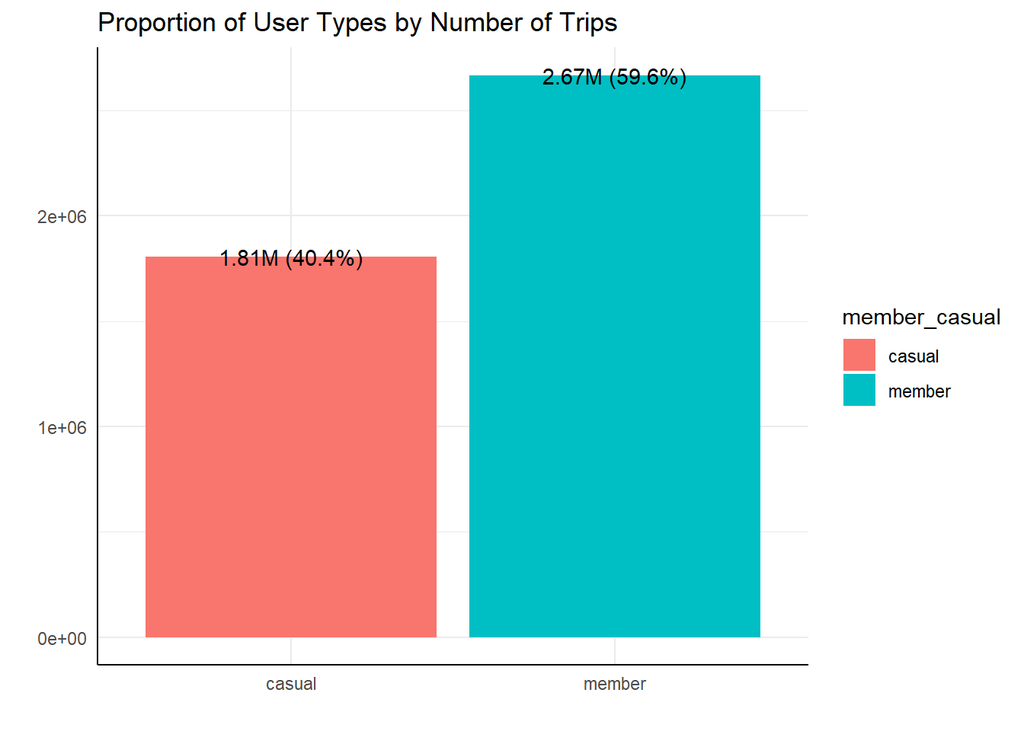

```r
all_valid_trips |>
  group_by(member_casual) |>
  summarise(number_of_trips = n()) |>
  ggplot(aes(x=member_casual, y=number_of_trips, fill = member_casual)) +
  geom_bar(stat = "identity") +
  theme_minimal()+
  ggtitle("Proportion of User Types by Number of Trips")+
  xlab("")+ylab("")+theme(axis.line = element_line(color='black'))+
  geom_text(aes(label=paste0(round((number_of_trips/1000000),2),"M ",
                             paste0("(",round((number_of_trips/num_of_valid_trips)*100,1),"%",")"))))
```

#### What is the most used bike types by membership types?

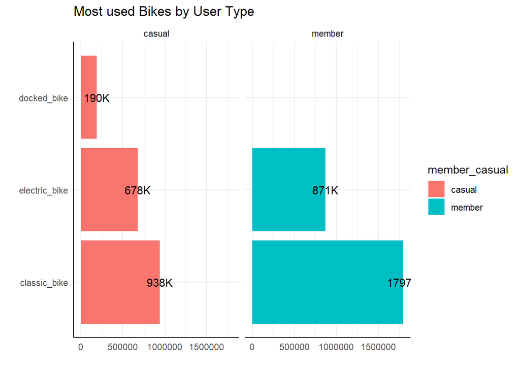

```r
all_valid_trips %>%
  group_by(member_casual, bike_id) %>%
  summarise(avg_trip_duration = mean(trip_duration), number_of_trips = n(), .groups="keep") %>%
  ggplot(aes(x=reorder(bike_id, -number_of_trips), y=number_of_trips, fill=member_casual))+
  geom_bar(stat = "identity") +
  theme_minimal()+
  ggtitle("Most used Bikes by User Type")+
  xlab("")+ylab("")+theme(axis.line = element_line(color='black'))+
  geom_text(aes(label=paste0(round((number_of_trips/1000),0),"K")))+
  coord_flip()+
  facet_wrap(~member_casual)
```

#### What is the average trip duration by membership type?

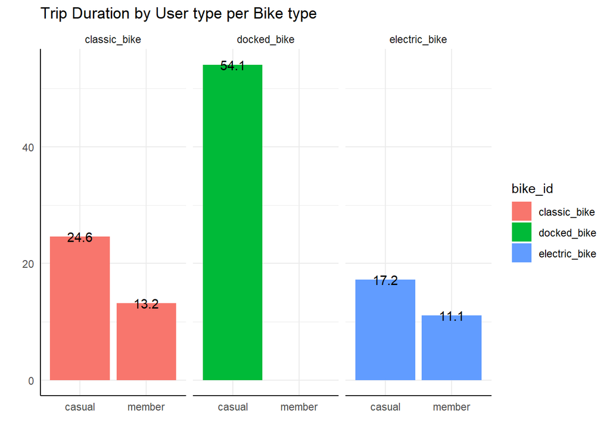

```r
all_valid_trips %>%
  group_by(member_casual, bike_id) %>%
  summarise(avg_trip_duration = mean(trip_duration), number_of_trips = n(), .groups = "keep") %>%
  ggplot(aes(x=member_casual, y=avg_trip_duration, fill=bike_id))+
  geom_bar(stat = "identity")+
  theme_minimal()+
  ggtitle("Trip Duration by User type per Bike type")+
  xlab("")+ylab("")+theme(axis.line = element_line(color='black'))+
  geom_text(aes(label=round(avg_trip_duration,1)))+
  facet_wrap(~bike_id)
```

#### Which week day do casual riders have peak bike usage?

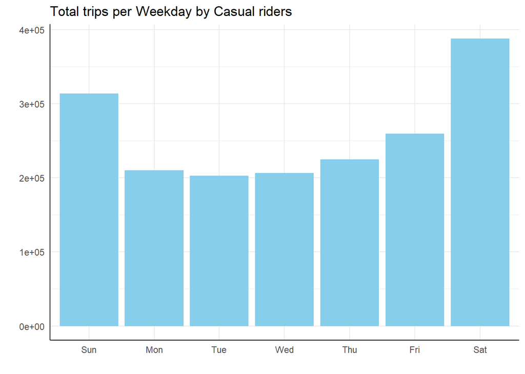

```r
all_valid_trips %>%
  filter(member_casual=="casual") |>
  group_by(week_day, wday) %>%
  summarise(avg_trip_duration = mean(trip_duration), number_of_trips = n()) %>%
  ggplot(aes(x=week_day, y=number_of_trips)) +
  geom_bar(stat = "identity", fill = "sky blue") +
  theme_minimal()+
  ggtitle("Total trips per Weekday by Casual riders")+
  xlab("")+ylab("")+theme(axis.line = element_line(color='black'))
```

#### Which week days do annual members have peak bike usage?

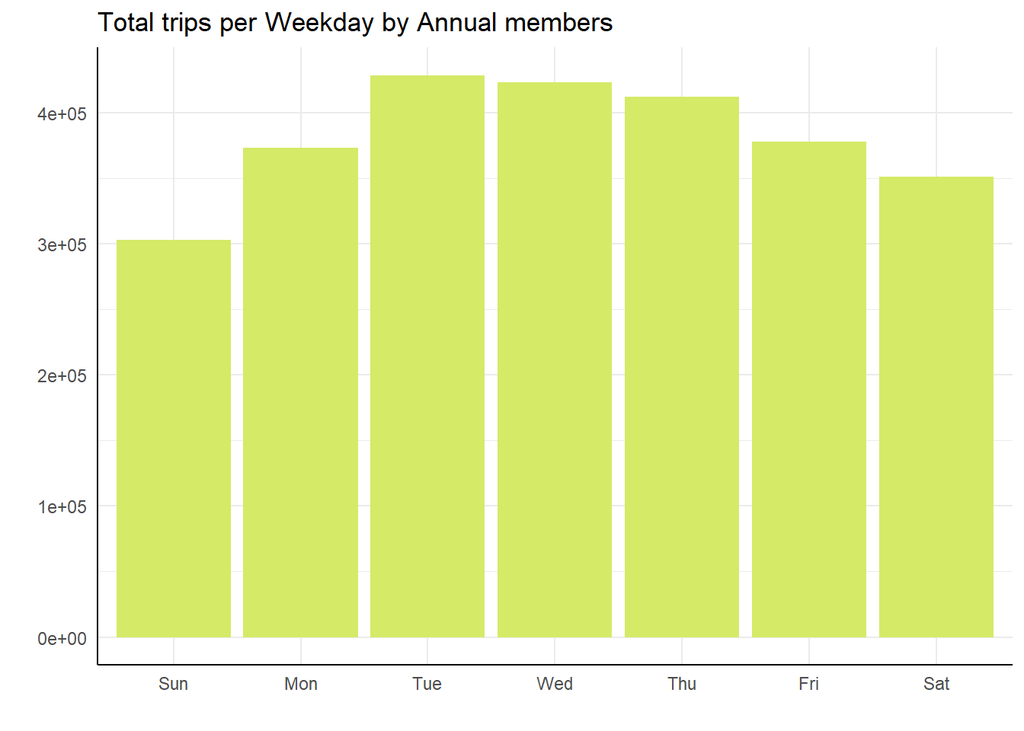

```r
all_valid_trips %>%
  filter(member_casual=="member") %>%
  group_by(week_day, wday) %>%
  summarise(avg_trip_duration = mean(trip_duration), number_of_trips = n()) %>%
  ggplot(aes(x=week_day, y=number_of_trips)) +
  geom_bar(stat = "identity", fill = "#D5EA67") +
  theme_minimal()+
  ggtitle("Total trips per Weekday by Annual members")+
  xlab("")+ylab("")+theme(axis.line = element_line(color='black'))
```

#### Which week days do the membership types record highest average trip duration?

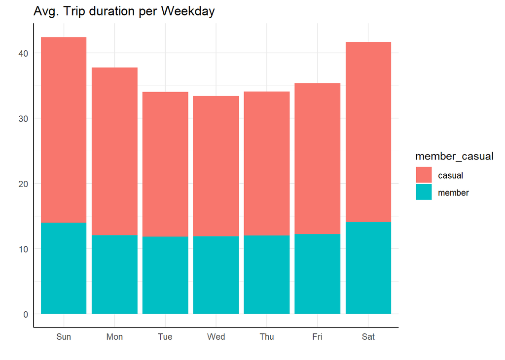

```r
all_valid_trips %>%
  group_by(week_day, wday, member_casual) %>%
  summarise(avg_trip_duration = mean(trip_duration), number_of_trips = n()) %>%
  ggplot(aes(x=week_day, y=avg_trip_duration, fill=member_casual)) +
  geom_bar(stat = "identity") +
  theme_minimal()+
  ggtitle("Avg. Trip duration per Weekday")+
  xlab("")+ylab("")+theme(axis.line = element_line(color='black'))
```

#### What are the most used routes by the membership types?

To evaluate this measure, there is need to create the route column

```r
all_valid_trips$route <- paste(all_valid_trips$start_station_name, "_to_", all_valid_trips$end_station_name)

head(all_valid_trips$route)
```

```
## [1] "Michigan Ave & Oak St _to_ Michigan Ave & Oak St"
## [2] "Desplaines St & Kinzie St _to_ Kingsbury St & Kinzie St"
## [3] "Michigan Ave & Oak St _to_ Michigan Ave & Oak St"
## [4] "Michigan Ave & Oak St _to_ Michigan Ave & Oak St"
## [5] "Kingsbury St & Kinzie St _to_ Desplaines St & Kinzie St"
## [6] "Sheridan Rd & Noyes St (NU) _to_ Sheridan Rd & Noyes St (NU)"
```

#### Most used routes by casual riders

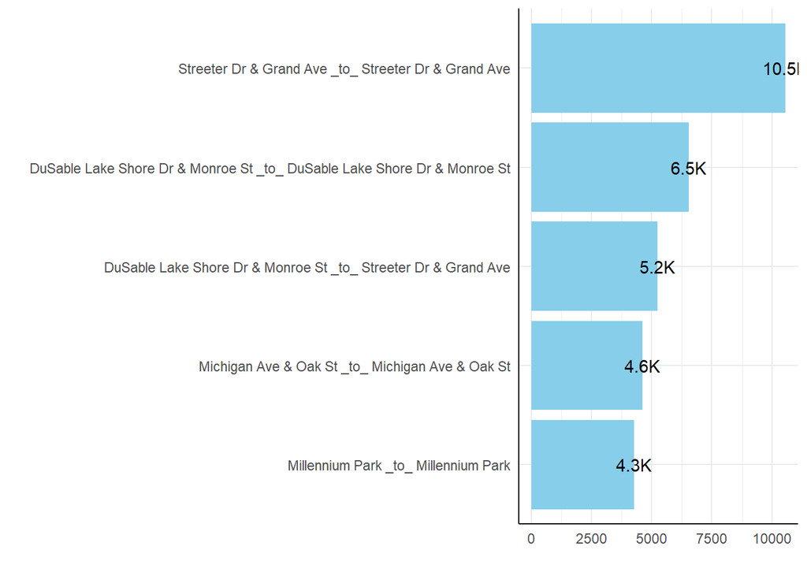

```r
all_valid_trips %>%
  filter(member_casual == "casual") |>
  group_by(route) %>%
  summarise(avg_trip_duration = mean(trip_duration), number_of_trips = n(), .groups = "keep") %>%
  arrange(-number_of_trips) |>
    head(5) |>
  ggplot(aes(x=reorder(route, +number_of_trips), y=number_of_trips))+
  geom_bar(stat = "identity", fill="sky blue")+
  theme_minimal()+
  geom_text(aes(label=paste0(round((number_of_trips/1000),1),"K")))+
  xlab("")+ylab("")+theme(axis.line = element_line(color='black'))+
  coord_flip()
```

#### Most used routes by annual members

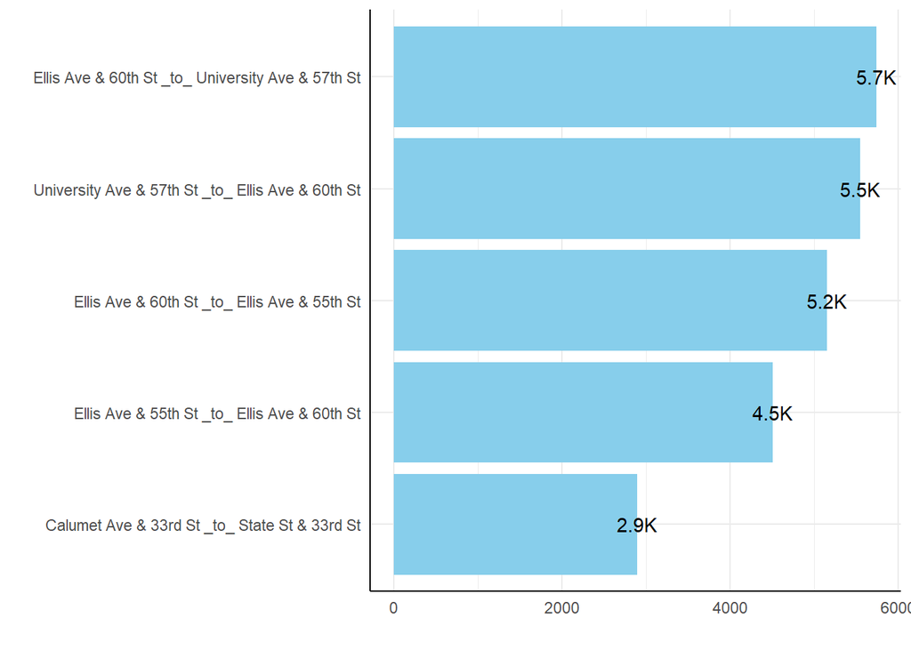

```r
all_valid_trips %>%
  filter(member_casual == "member") %>%
  group_by(route) %>%
  summarise(avg_trip_duration = mean(trip_duration), number_of_trips = n(), .groups = "keep") %>%
  arrange(-number_of_trips) %>%
    head(5) %>%
  ggplot(aes(x=reorder(route, +number_of_trips), y=number_of_trips))+
  geom_bar(stat = "identity", fill="sky blue")+
  theme_minimal()+
  geom_text(aes(label=paste0(round((number_of_trips/1000),1),"K")))+
  xlab("")+ylab("")+theme(axis.line = element_line(color='black'))+
  coord_flip()
```